# TidyTemplate

2021-03-15

# TidyTuesday

Join the R4DS Online Learning Community in the weekly #TidyTuesday event! Every week we post a raw dataset, a chart or article related to that dataset, and ask you to explore the data. While the dataset will be “tamed”, it will not always be tidy! As such you might need to apply various R for Data Science techniques to wrangle the data into a true tidy format. The goal of TidyTuesday is to apply your R skills, get feedback, explore other’s work, and connect with the greater #RStats community! As such we encourage everyone of all skills to participate!

# Load the weekly Data

Dowload the weekly data and make available in the `tt` object.

```r
tt <- tt_load("2021-03-02")
```

```
## --- Compiling #TidyTuesday Information for 2021-03-02 ----
```

```
## --- There is 1 file available ---
```

```
## --- Starting Download ---
```

```
## --- Download complete ---
```

# Readme

Take a look at the readme for the weekly data to get insight on the dataset. This includes a data dictionary, source, and a link to an article on the data.

```r
tt
```

# Glimpse Data

Take an initial look at the format of the data available.

```r
tt %>%
  map(glimpse)
```

```
## Rows: 247
## Columns: 25
## $ year                      <dbl> 2018, 2020, 2006, 2018, 2003, 2020, 2020, 2…
## $ brand                     <chr> "Toyota", "Bud Light", "Bud Light", "Hynuda…
## $ superbowl_ads_dot_com_url <chr> "https://superbowl-ads.com/good-odds-toyota…
## $ youtube_url               <chr> "https://www.youtube.com/watch?v=zeBZvwYQ-h…
## $ funny                     <lgl> FALSE, TRUE, TRUE, FALSE, TRUE, TRUE, TRUE,…
## $ show_product_quickly      <lgl> FALSE, TRUE, FALSE, TRUE, TRUE, TRUE, FALSE…
## $ patriotic                 <lgl> FALSE, FALSE, FALSE, FALSE, FALSE, FALSE, F…
## $ celebrity                 <lgl> FALSE, TRUE, FALSE, FALSE, FALSE, TRUE, TRU…
## $ danger                    <lgl> FALSE, TRUE, TRUE, FALSE, TRUE, TRUE, FALSE…
## $ animals                   <lgl> FALSE, FALSE, TRUE, FALSE, TRUE, TRUE, TRUE…
## $ use_sex                   <lgl> FALSE, FALSE, FALSE, FALSE, TRUE, FALSE, FA…
## $ id                        <chr> "zeBZvwYQ-hA", "nbbp0VW7z8w", "yk0MQD5YgV8"…
## $ kind                      <chr> "youtube#video", "youtube#video", "youtube#…
## $ etag                      <chr> "rn-ggKNly38Cl0C3CNjNnUH9xUw", "1roDoK-SYqS…
## $ view_count                <dbl> 173929, 47752, 142310, 198, 13741, 23636, 3…
## $ like_count                <dbl> 1233, 485, 129, 2, 20, 115, 1470, 78, 342, …
## $ dislike_count             <dbl> 38, 14, 15, 0, 3, 11, 384, 6, 7, 0, 14, 0, …
## $ favorite_count            <dbl> 0, 0, 0, 0, 0, 0, 0, 0, 0, 0, 0, 0, 0, 0, 0…
## $ comment_count             <dbl> NA, 14, 9, 0, 2, 13, 227, 6, 30, 0, 8, 1, 1…
## $ published_at              <dttm> 2018-02-03 11:29:14, 2020-01-31 21:04:13, …
## $ title                     <chr> "Toyota Super Bowl Commercial 2018 Good Odd…
## $ description               <chr> "Toyota Super Bowl Commercial 2018 Good Odd…
## $ thumbnail                 <chr> "https://i.ytimg.com/vi/zeBZvwYQ-hA/sddefau…
## $ channel_title             <chr> "Funny Commercials", "VCU Brandcenter", "Jo…
## $ category_id               <dbl> 1, 27, 17, 22, 24, 1, 24, 2, 24, 24, 24, 24…
```

```
## $youtube
## # A tibble: 247 x 25
##     year brand superbowl_ads_d… youtube_url funny show_product_qu… patriotic
##    <dbl> <chr> <chr>            <chr>       <lgl> <lgl>            <lgl>
##  1  2018 Toyo… https://superbo… https://ww… FALSE FALSE            FALSE
##  2  2020 Bud … https://superbo… https://ww… TRUE  TRUE             FALSE
##  3  2006 Bud … https://superbo… https://ww… TRUE  FALSE            FALSE
##  4  2018 Hynu… https://superbo… https://ww… FALSE TRUE             FALSE
##  5  2003 Bud … https://superbo… https://ww… TRUE  TRUE             FALSE
##  6  2020 Toyo… https://superbo… https://ww… TRUE  TRUE             FALSE
##  7  2020 Coca… https://superbo… https://ww… TRUE  FALSE            FALSE
##  8  2020 Kia   https://superbo… https://ww… FALSE FALSE            FALSE
##  9  2020 Hynu… https://superbo… https://ww… TRUE  TRUE             FALSE
## 10  2020 Budw… https://superbo… https://ww… FALSE TRUE             TRUE
## # … with 237 more rows, and 18 more variables: celebrity <lgl>, danger <lgl>,
## #   animals <lgl>, use_sex <lgl>, id <chr>, kind <chr>, etag <chr>,
## #   view_count <dbl>, like_count <dbl>, dislike_count <dbl>,
## #   favorite_count <dbl>, comment_count <dbl>, published_at <dttm>,
## #   title <chr>, description <chr>, thumbnail <chr>, channel_title <chr>,
## #   category_id <dbl>
```

```r
skimr::skim(tt$youtube)
```

Data summary

| Name | tt$youtube |
| --- | --- |
| Number of rows | 247 |
| Number of columns | 25 |
| _______________________ |  |
| Column type frequency: |  |
| character | 10 |
| logical | 7 |
| numeric | 7 |
| POSIXct | 1 |
| ________________________ |  |
| Group variables | None |

**Variable type: character**

| skim_variable | n_missing | complete_rate | min | max | empty | n_unique | whitespace |
| --- | --- | --- | --- | --- | --- | --- | --- |
| brand | 0 | 1.00 | 3 | 9 | 0 | 10 | 0 |
| superbowl_ads_dot_com_url | 0 | 1.00 | 34 | 120 | 0 | 244 | 0 |
| youtube_url | 11 | 0.96 | 43 | 43 | 0 | 233 | 0 |
| id | 11 | 0.96 | 11 | 11 | 0 | 233 | 0 |
| kind | 16 | 0.94 | 13 | 13 | 0 | 1 | 0 |
| etag | 16 | 0.94 | 27 | 27 | 0 | 228 | 0 |
| title | 16 | 0.94 | 6 | 99 | 0 | 228 | 0 |
| description | 50 | 0.80 | 3 | 3527 | 0 | 194 | 0 |
| thumbnail | 129 | 0.48 | 48 | 48 | 0 | 118 | 0 |
| channel_title | 16 | 0.94 | 3 | 37 | 0 | 185 | 0 |

**Variable type: logical**

| skim_variable | n_missing | complete_rate | mean | count |
| --- | --- | --- | --- | --- |
| funny | 0 | 1 | 0.69 | TRU: 171, FAL: 76 |
| show_product_quickly | 0 | 1 | 0.68 | TRU: 169, FAL: 78 |
| patriotic | 0 | 1 | 0.17 | FAL: 206, TRU: 41 |
| celebrity | 0 | 1 | 0.29 | FAL: 176, TRU: 71 |
| danger | 0 | 1 | 0.30 | FAL: 172, TRU: 75 |
| animals | 0 | 1 | 0.37 | FAL: 155, TRU: 92 |
| use_sex | 0 | 1 | 0.27 | FAL: 181, TRU: 66 |

**Variable type: numeric**

| skim_variable | n_missing | complete_rate | mean | sd | p0 | p25 | p50 | p75 | p100 | hist |
| --- | --- | --- | --- | --- | --- | --- | --- | --- | --- | --- |
| year | 0 | 1.00 | 2010.19 | 5.86 | 2000 | 2005 | 2010 | 2015.00 | 2020 | ▇▇▇▇▆ |
| view_count | 16 | 0.94 | 1407556.46 | 11971111.01 | 10 | 6431 | 41379 | 170015.50 | 176373378 | ▇▁▁▁▁ |
| like_count | 22 | 0.91 | 4146.03 | 23920.40 | 0 | 19 | 130 | 527.00 | 275362 | ▇▁▁▁▁ |
| dislike_count | 22 | 0.91 | 833.54 | 6948.52 | 0 | 1 | 7 | 24.00 | 92990 | ▇▁▁▁▁ |
| favorite_count | 16 | 0.94 | 0.00 | 0.00 | 0 | 0 | 0 | 0.00 | 0 | ▁▁▇▁▁ |
| comment_count | 25 | 0.90 | 188.64 | 986.46 | 0 | 1 | 10 | 50.75 | 9190 | ▇▁▁▁▁ |
| category_id | 16 | 0.94 | 19.32 | 8.00 | 1 | 17 | 23 | 24.00 | 29 | ▃▁▂▆▇ |

**Variable type: POSIXct**

| skim_variable | n_missing | complete_rate | min | max | median | n_unique |
| --- | --- | --- | --- | --- | --- | --- |
| published_at | 16 | 0.94 | 2006-02-06 10:02:36 | 2021-01-27 13:11:29 | 2013-01-31 09:13:55 | 227 |

```r
youtube <- tt$youtube %>%
  select(-favorite_count) %>%
  mutate(brand = fct_recode(brand, Hyundai = "Hynudai"))
```

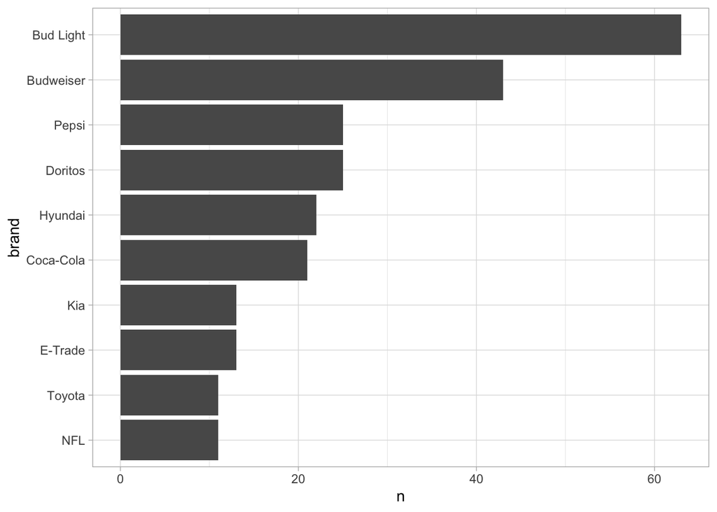

```r
youtube %>%
  count(brand, sort = TRUE) %>%
  head(20) %>%
  mutate(brand = fct_reorder(brand, n)) %>%
  ggplot(aes(n, brand)) +
  geom_col()
```

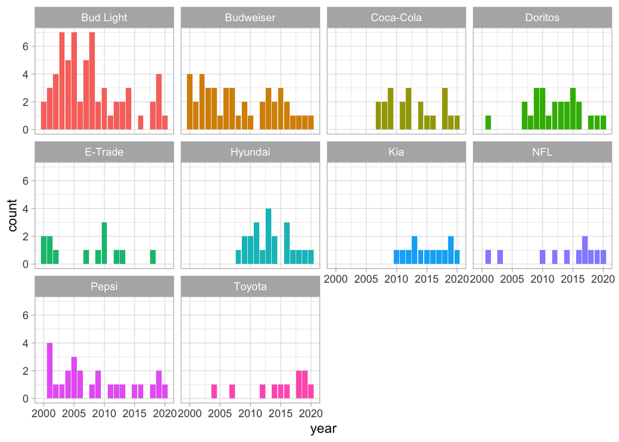

```r
youtube %>%
  ggplot(aes(year, fill = brand)) +
  geom_bar() +
  facet_wrap(~ brand) +
  theme(legend.position = "none")
```

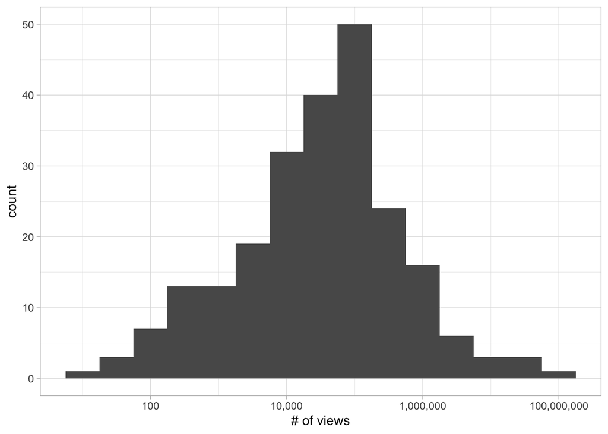

```r
youtube %>%
  ggplot(aes(view_count)) +
  geom_histogram(binwidth = .5) +
  scale_x_log10(labels = comma) +
  labs(x = "# of views")
```

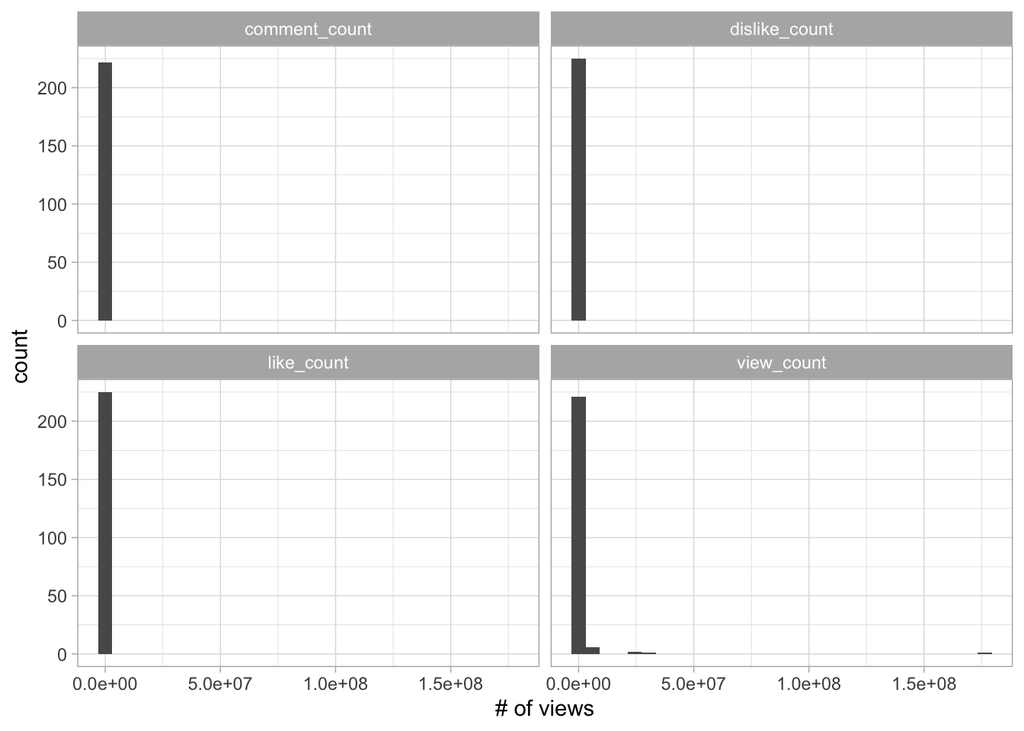

```r
youtube %>%
  gather(metric, value, contains("_count")) %>%
  ggplot(aes(value)) +
  geom_histogram() +
#  scale_x_log10(labels = comma) +
  labs(x = "# of views") +
  facet_wrap(~ metric)
```

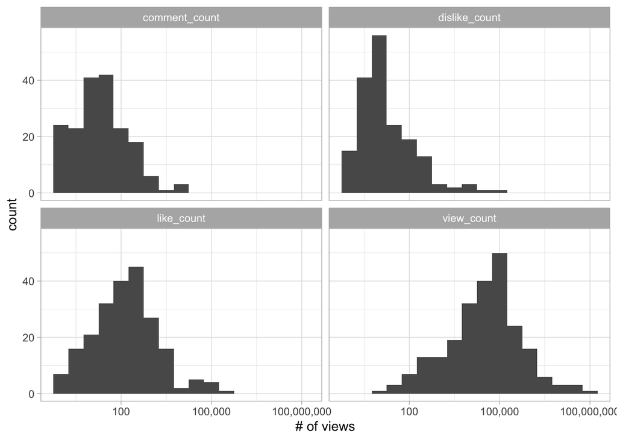

```r
youtube %>%
  gather(metric, value, contains("_count")) %>%
  ggplot(aes(value)) +
  geom_histogram(binwidth = .5) +
  scale_x_log10(labels = comma) +
  labs(x = "# of views") +
  facet_wrap(~ metric)
```

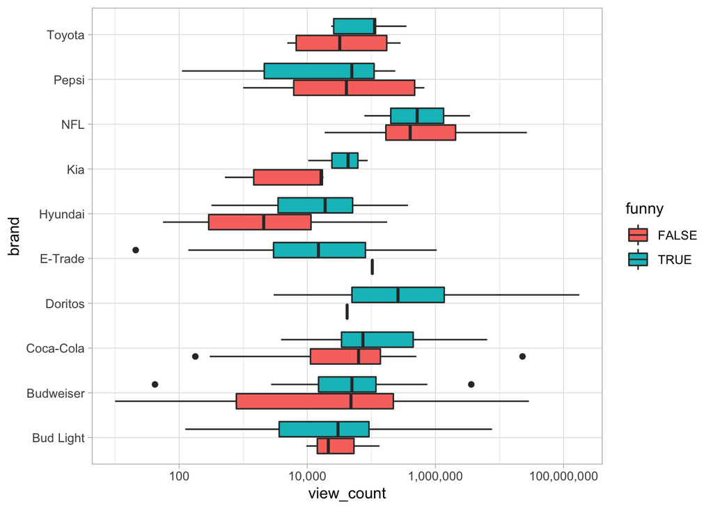

```r
youtube %>%
  filter(!is.na(view_count)) %>%
#  mutate(brand = fct_reorder(brand, view_count)) %>%
  ggplot(aes(view_count, brand, fill = funny)) +
  geom_boxplot() +
  scale_x_log10(labels = comma)
```

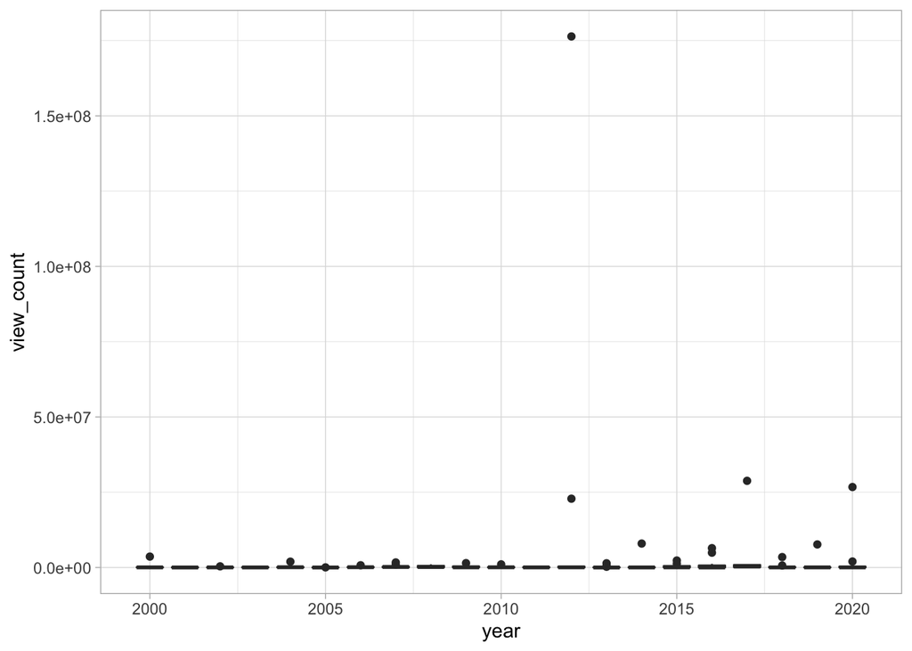

```r
youtube %>%
  ggplot(aes(year, view_count, group = year)) +
  geom_boxplot()
```

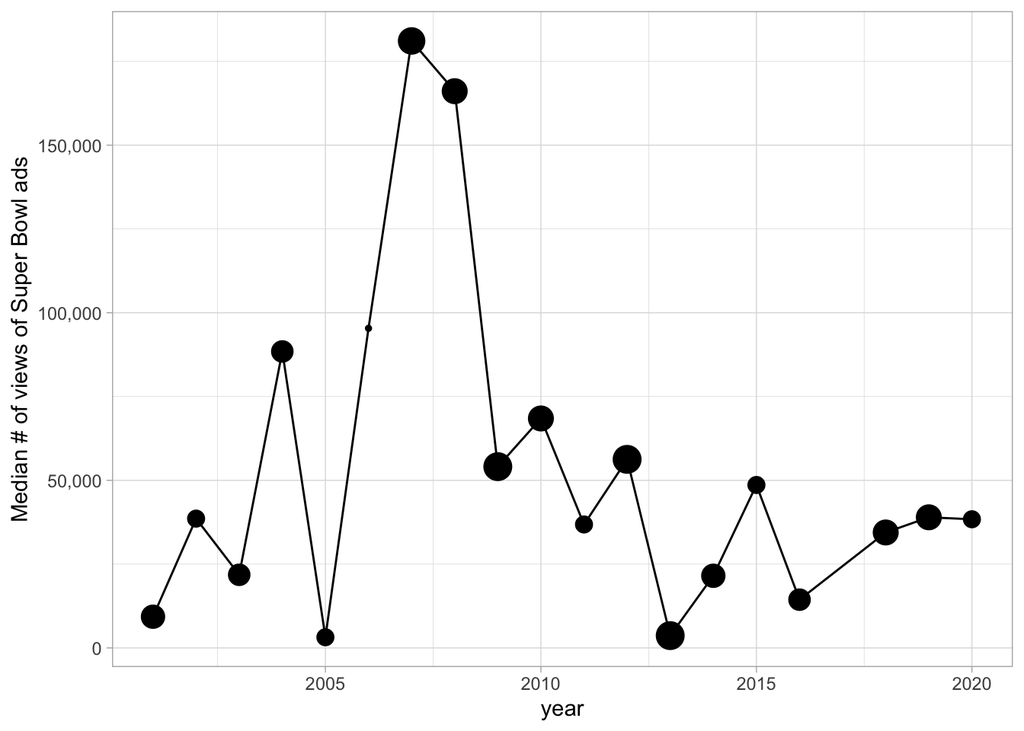

```r
youtube %>%
  filter(!is.na(view_count)) %>%
  group_by(year) %>%
  summarize(n = n(),
            median_views = median(view_count)) %>%
  filter(n >= 7) %>%
  ggplot(aes(year, median_views)) +
  geom_line() +
  geom_point(aes(size = n)) +
  scale_y_continuous(labels = comma) +
  theme(legend.position = "none") +
  labs(y = "Median # of views of Super Bowl ads")
```

```r
gathered_categories <- youtube %>%
  gather(category, value, funny:use_sex) %>%
  mutate(category = str_to_title(str_replace_all(category, "_", " ")))

glimpse(gathered_categories)
```

```
## Rows: 1,729
## Columns: 19
## $ year                      <dbl> 2018, 2020, 2006, 2018, 2003, 2020, 2020, 2…
## $ brand                     <fct> Toyota, Bud Light, Bud Light, Hyundai, Bud …
## $ superbowl_ads_dot_com_url <chr> "https://superbowl-ads.com/good-odds-toyota…
## $ youtube_url               <chr> "https://www.youtube.com/watch?v=zeBZvwYQ-h…
## $ id                        <chr> "zeBZvwYQ-hA", "nbbp0VW7z8w", "yk0MQD5YgV8"…
## $ kind                      <chr> "youtube#video", "youtube#video", "youtube#…
## $ etag                      <chr> "rn-ggKNly38Cl0C3CNjNnUH9xUw", "1roDoK-SYqS…
## $ view_count                <dbl> 173929, 47752, 142310, 198, 13741, 23636, 3…
## $ like_count                <dbl> 1233, 485, 129, 2, 20, 115, 1470, 78, 342, …
## $ dislike_count             <dbl> 38, 14, 15, 0, 3, 11, 384, 6, 7, 0, 14, 0, …
## $ comment_count             <dbl> NA, 14, 9, 0, 2, 13, 227, 6, 30, 0, 8, 1, 1…
## $ published_at              <dttm> 2018-02-03 11:29:14, 2020-01-31 21:04:13, …
## $ title                     <chr> "Toyota Super Bowl Commercial 2018 Good Odd…
## $ description               <chr> "Toyota Super Bowl Commercial 2018 Good Odd…
## $ thumbnail                 <chr> "https://i.ytimg.com/vi/zeBZvwYQ-hA/sddefau…
## $ channel_title             <chr> "Funny Commercials", "VCU Brandcenter", "Jo…
## $ category_id               <dbl> 1, 27, 17, 22, 24, 1, 24, 2, 24, 24, 24, 24…
## $ category                  <chr> "Funny", "Funny", "Funny", "Funny", "Funny"…
## $ value                     <lgl> FALSE, TRUE, TRUE, FALSE, TRUE, TRUE, TRUE,…
```

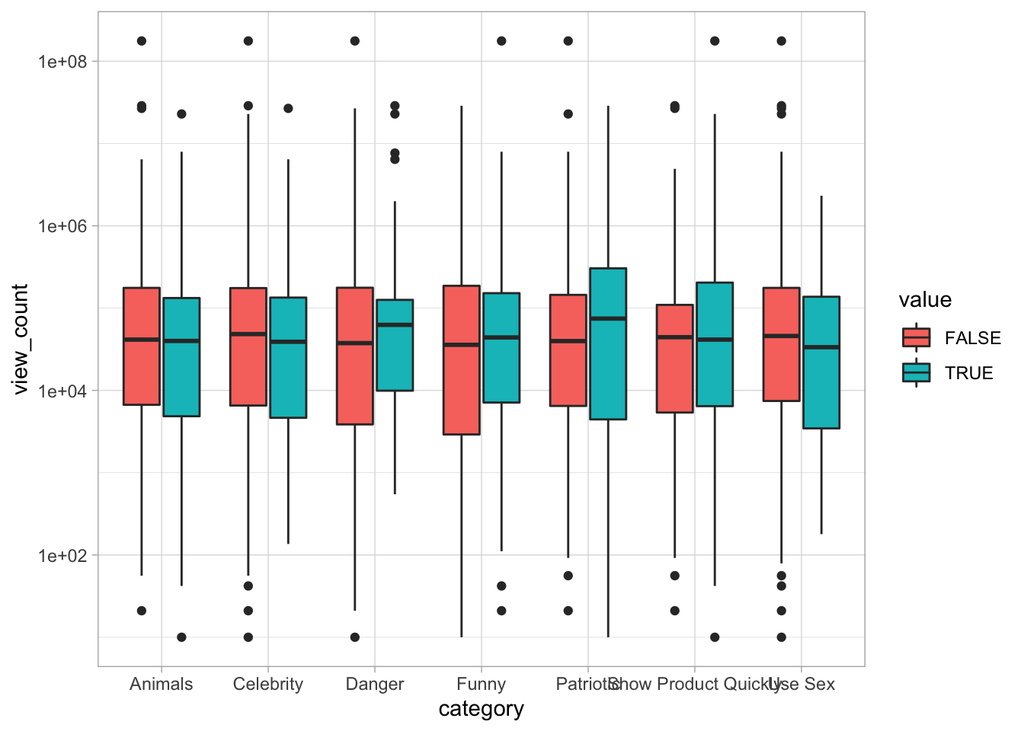

```r
gathered_categories %>%
  ggplot(aes(category, view_count, fill = value)) +
  geom_boxplot() +
  scale_y_log10()
```

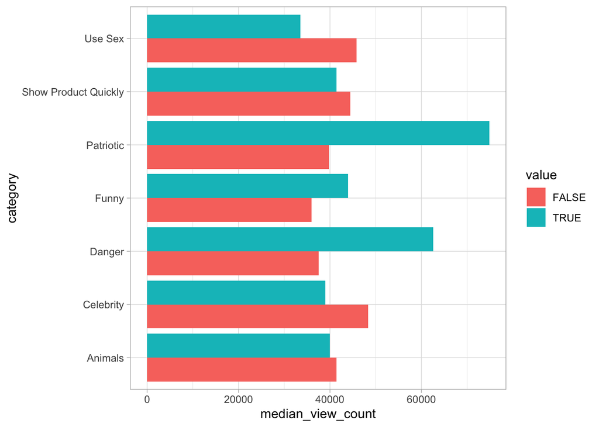

```r
gathered_categories %>%
  filter(!is.na(view_count)) %>%
  group_by(category, value) %>%
  summarize(n = n(),
            median_view_count = median(view_count)) %>%
  ggplot(aes(median_view_count, category, fill = value)) +
  geom_col(position = "dodge")
```

```r
gathered_categories %>%
  filter(!is.na(view_count)) %>%
  group_by(category) %>%
  summarize(correlation = cor(value, log(view_count+1))) %>%
  arrange(desc(correlation))
```

```
## # A tibble: 7 x 2
##   category             correlation
##   <chr>                      <dbl>
## 1 Danger                   0.107
## 2 Funny                    0.0686
## 3 Show Product Quickly     0.0348
## 4 Patriotic                0.0255
## 5 Celebrity                0.00303
## 6 Animals                 -0.0295
## 7 Use Sex                 -0.0520
```

```r
lm(log2(view_count) ~ danger + patriotic + funny + show_product_quickly + celebrity + animals + use_sex,
   data = youtube) %>%
  summary()
```

```
##
## Call:
## lm(formula = log2(view_count) ~ danger + patriotic + funny +
##     show_product_quickly + celebrity + animals + use_sex, data = youtube)
##
## Residuals:
##      Min       1Q   Median       3Q      Max
## -11.4053  -2.2006   0.1322   2.2986  12.2874
##
## Coefficients:
##                          Estimate Std. Error t value Pr(>|t|)
## (Intercept)               14.0569     0.7224  19.458   <2e-16 ***
## dangerTRUE                 0.9167     0.6030   1.520    0.130
## patrioticTRUE              0.7831     0.7704   1.016    0.310
## funnyTRUE                  0.7292     0.6569   1.110    0.268
## show_product_quicklyTRUE   0.3205     0.5838   0.549    0.584
## celebrityTRUE              0.1328     0.5933   0.224    0.823
## animalsTRUE               -0.4333     0.5669  -0.764    0.445
## use_sexTRUE               -0.6258     0.6349  -0.986    0.325
## ---
## Signif. codes:  0 '***' 0.001 '**' 0.01 '*' 0.05 '.' 0.1 ' ' 1
##
## Residual standard error: 4.02 on 223 degrees of freedom
##   (16 observations deleted due to missingness)
## Multiple R-squared:  0.02545,    Adjusted R-squared:  -0.005137
## F-statistic: 0.8321 on 7 and 223 DF,  p-value: 0.5616
```

```r
glm(celebrity ~ year,
    data = youtube,
    family = "binomial") %>%
  summary()
```

```
##
## Call:
## glm(formula = celebrity ~ year, family = "binomial", data = youtube)
##
## Deviance Residuals:
##     Min       1Q   Median       3Q      Max
## -1.0244  -0.8539  -0.7441   1.3244   1.8574
##
## Coefficients:
##               Estimate Std. Error z value Pr(>|z|)
## (Intercept) -130.20092   50.15284  -2.596  0.00943 **
## year           0.06430    0.02494   2.579  0.00992 **
## ---
## Signif. codes:  0 '***' 0.001 '**' 0.01 '*' 0.05 '.' 0.1 ' ' 1
##
## (Dispersion parameter for binomial family taken to be 1)
##
##     Null deviance: 296.33  on 246  degrees of freedom
## Residual deviance: 289.44  on 245  degrees of freedom
## AIC: 293.44
##
## Number of Fisher Scoring iterations: 4
```

```r
coefficients <- gathered_categories %>%
  group_by(category) %>%
  summarize(model = list(glm(value ~ year, family = "binomial"))) %>%
  mutate(td = map(model, broom::tidy)) %>%
  unnest(td) %>%
  filter(term != "(Intercept)") %>%
  arrange(desc(estimate))
```

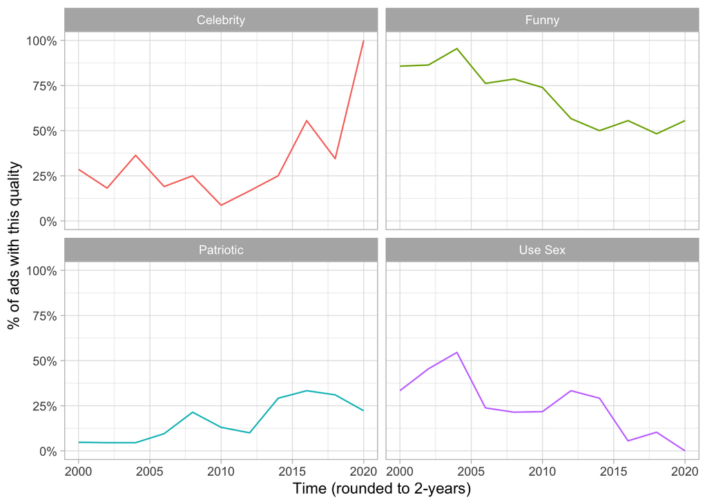

```r
gathered_categories %>%
  group_by(category,
           year = 2 * (year %/% 2)) %>%
  summarize(pct = mean(value),
            n = n()) %>%
  inner_join(coefficients, by = "category") %>%
  filter(p.value <= .01) %>%
  ggplot(aes(year, pct, color = category)) +
  geom_line() +
  scale_y_continuous(labels = percent) +
  facet_wrap(~ category) +
  theme(legend.position = "none") +
  labs(x = "Time (rounded to 2-years)",
       y = "% of ads with this quality")
```

```r
library(tidytext)

by_brand_category <- gathered_categories %>%
  group_by(brand, category) %>%
  summarize(pct = mean(value)) %>%
  ungroup()
by_brand_category
```

```
## # A tibble: 70 x 3
##    brand     category                pct
##    <fct>     <chr>                 <dbl>
##  1 Bud Light Animals              0.381
##  2 Bud Light Celebrity            0.270
##  3 Bud Light Danger               0.429
##  4 Bud Light Funny                0.952
##  5 Bud Light Patriotic            0.0476
##  6 Bud Light Show Product Quickly 0.825
##  7 Bud Light Use Sex              0.429
##  8 Budweiser Animals              0.558
##  9 Budweiser Celebrity            0.116
## 10 Budweiser Danger               0.163
## # … with 60 more rows
```

## reorder_within() / scale_y_reordered() hack for getting facetted plots to look nice:

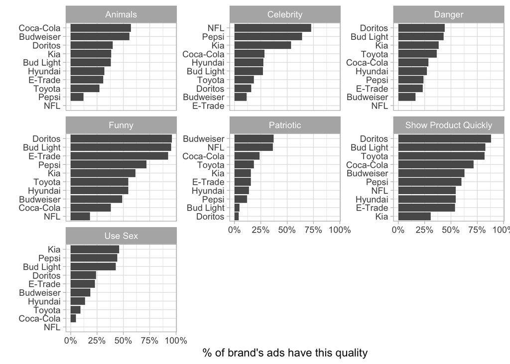

```r
by_brand_category %>%
  mutate(brand = reorder_within(brand, pct, category)) %>%
  ggplot(aes(pct, brand)) +
  geom_col() +
  scale_x_continuous(labels = percent) +
  scale_y_reordered() +
  facet_wrap(~ category, scales = "free_y") +
  labs(y = "",
       x = "% of brand's ads have this quality")
```

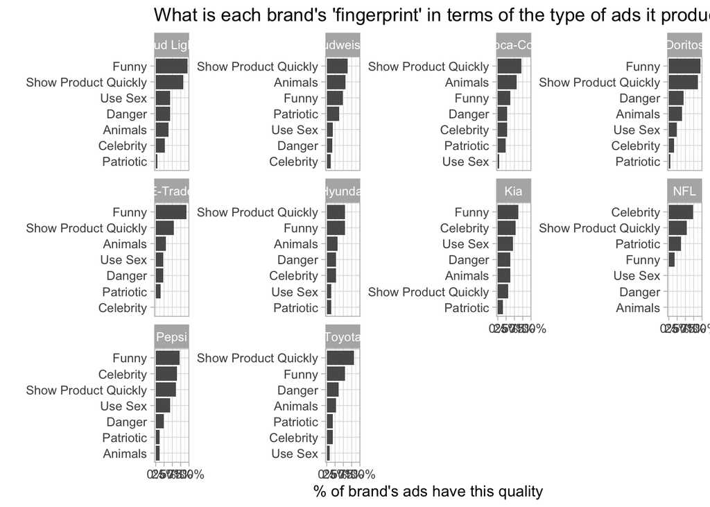

```r
by_brand_category %>%
  mutate(category = reorder_within(category, pct, brand)) %>%
  ggplot(aes(pct, category)) +
  geom_col() +
  scale_x_continuous(labels = percent) +
  scale_y_reordered() +
  facet_wrap(~ brand, scales = "free_y") +
  labs(y = "",
       x = "% of brand's ads have this quality") +
  labs(title = "What is each brand's 'fingerprint' in terms of the type of ads it produces?")
```

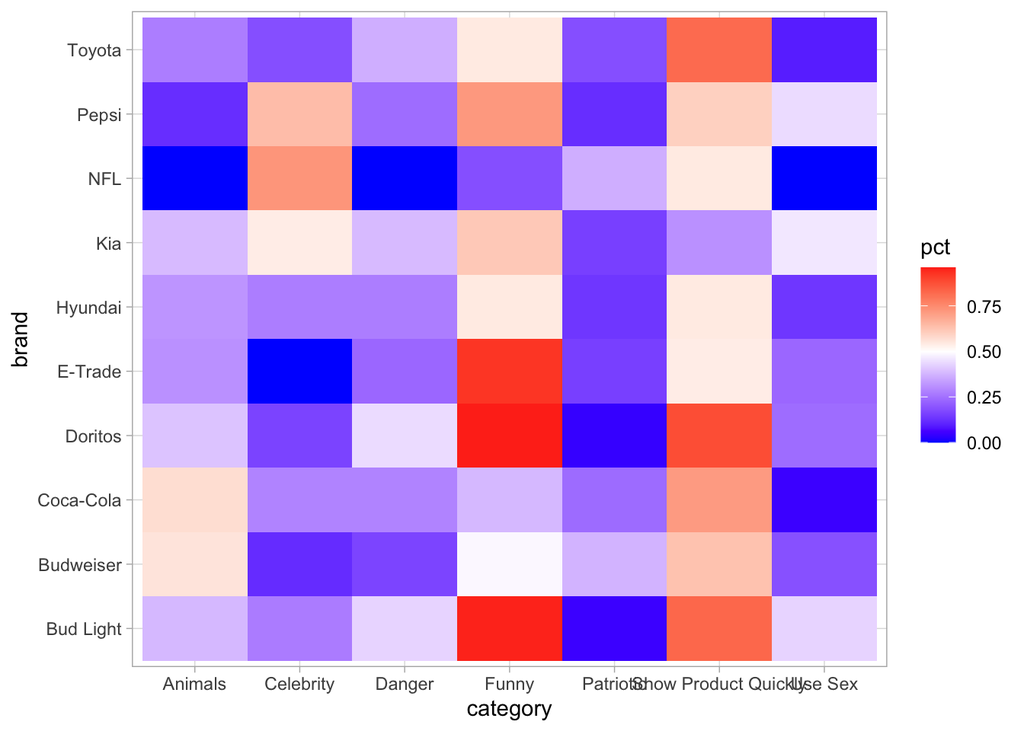

```r
by_brand_category %>%
  ggplot(aes(category, brand, fill = pct)) +
  geom_tile() +
  scale_fill_gradient2(low = "blue", high = "red", midpoint = .5)
```

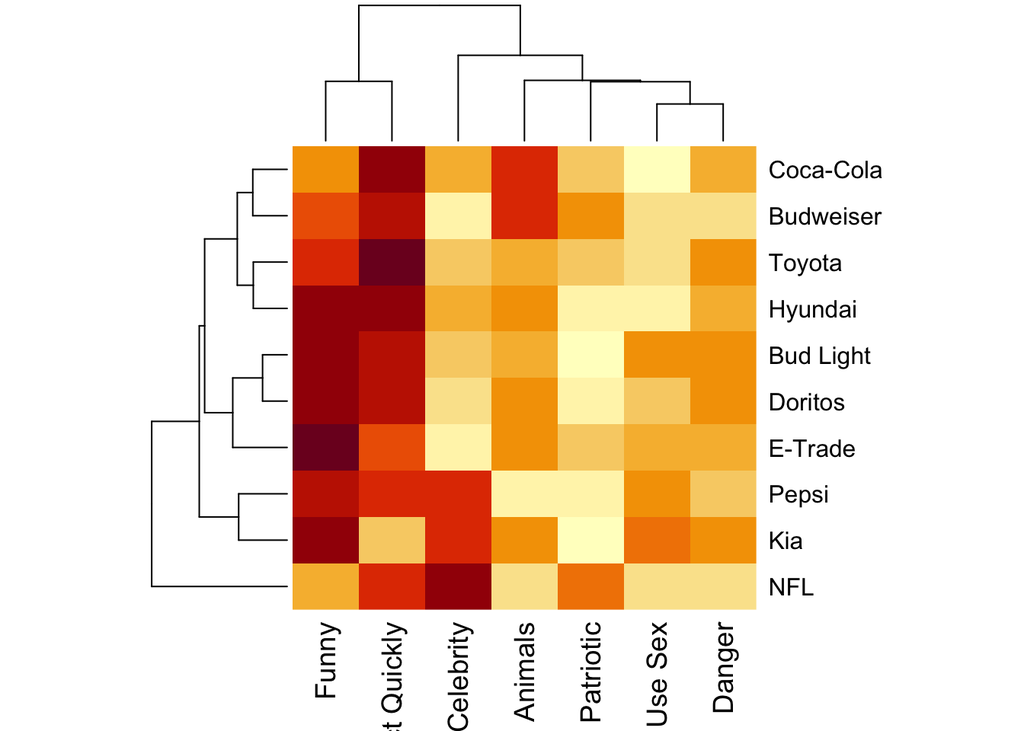

```r
by_brand_category %>%
  reshape2::acast(brand ~ category, value.var = "pct") %>%
  heatmap()
```

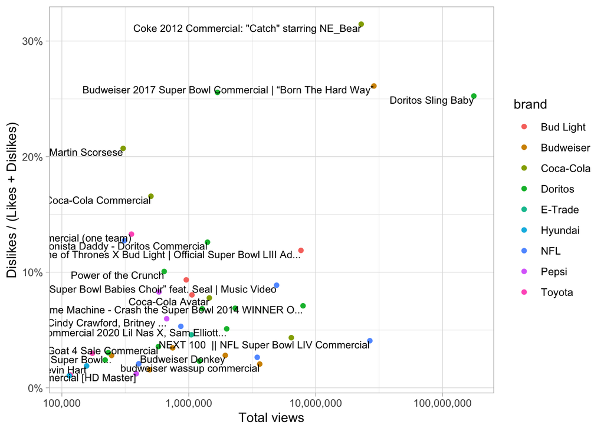

```r
likes_dislikes <- youtube %>%
  mutate(dislike_pct = dislike_count / view_count,
         like_ratio = like_count / dislike_count) %>%
  mutate(like_dislike_total = like_count + dislike_count) %>%
  filter(like_dislike_total >= 500) %>%
  filter(!is.na(dislike_pct)) %>%
  select(brand, year, title, description, view_count, like_dislike_total, like_count,
         dislike_count, like_ratio) %>%
  mutate(dislike_pct = dislike_count / (like_count + dislike_count)) %>%
  arrange(desc(view_count))

likes_dislikes %>%
  filter(like_dislike_total >= 1000) %>%
  ggplot(aes(view_count, dislike_pct)) +
  geom_point(aes(color = brand)) +
  scale_x_log10(labels = comma) +
  scale_y_continuous(labels = percent) +
  geom_text(aes(label = str_trunc(title, 60)),
            check_overlap = TRUE, vjust = 1,
            hjust = 1, size = 3) +
  labs(x = "Total views",
       y = "Dislikes / (Likes + Dislikes)")
```

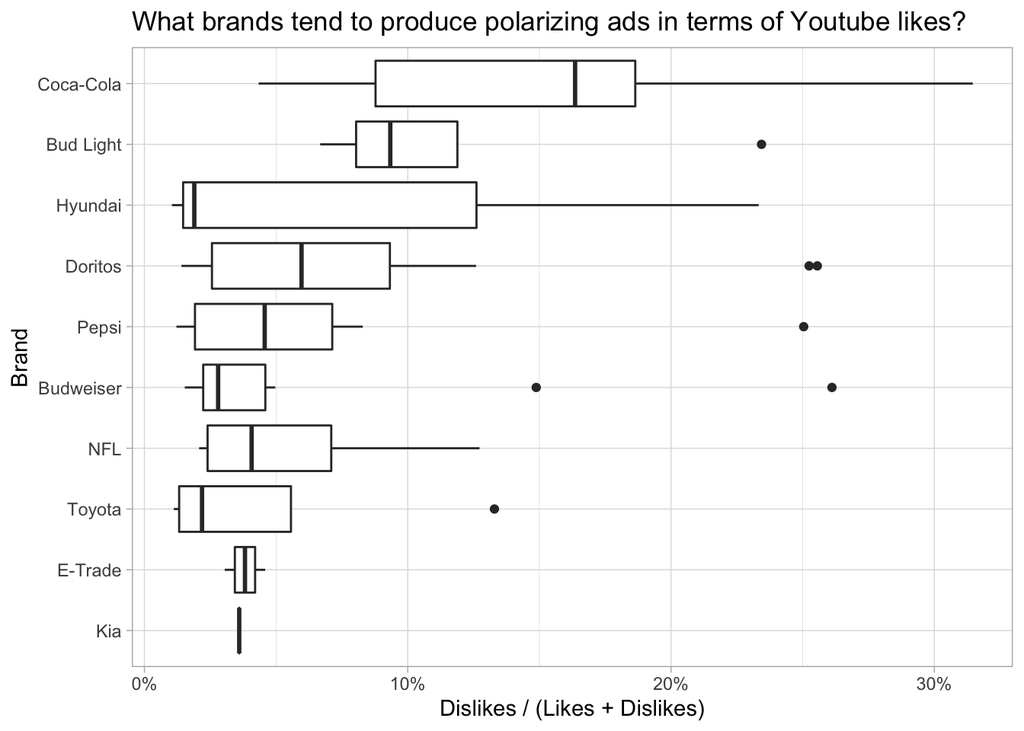

```r
likes_dislikes %>%
  mutate(brand = fct_reorder(brand, dislike_pct, mean)) %>%
  ggplot(aes(dislike_pct, brand)) +
  geom_boxplot() +
  scale_x_continuous(labels = percent) +
  labs(title = "What brands tend to produce polarizing ads in terms of Youtube likes?",
       x = "Dislikes / (Likes + Dislikes)",
       y = "Brand")
```